# Assignment 1: Oakland’s TOD

Alex Nelms

10/5/2021

# The East Bay & Transit Oriented Developments

**A Study of the Bay Area Rapid Transit and the Major Cities in the Eastern part of the San Francisco Bay Area**

The San Francisco Bay Area’s East Bay Housing Crisis is the resulting clash of strict land-use regulations, racial housing discrimination, and missing regional government with the explosive growth of the technology industry. This mismatch has led to increasing rent, homelessness, and *‘gentrification’* on a crisis-level scale.

Even though the Bay Area’s economy has grew to become the [18th largest economy in the world in 2017](http://www.bayareaeconomy.org/bay-area-gdp-surges-in-2017-now-worlds-18th-largest-economy/), the housing market has not. Also ratified in 2017 was the region’s [Plan Bay Area 2040](http://2040.planbayarea.org/) — which had bay area cities set 2040 housing targets. Two cities at the heart of the plan, Oakland and Berkeley, are already forecasted to meet their 2040 targets [far beyond 2070](https://mtc.ca.gov/node/125196%3E).

> “Every single county is over-performing its job forecast, some by massive amounts, and every single county is under-performing its housing forecast, almost all by a wide margin,”

> — *MTC director Steve Heminger in his [report to the Association of Bay Area Governments executive board](https://web.archive.org/web/20180706121145/https://www.sfgate.com/bayarea/article/bay-area-housing-shortage-how-long-to-fix-mtc-13034136.php)*

The East Bay has been at the center of this mismatch, especially for the urban corridor [Figure 1] of Oakland, Berkeley, and immediate surrounding cities: Alameda, Piedmont, Albany, & Emeryville. The urban East Bay, between the 2009 and 2019 American Community Surveys, added 62,869 residents (10% increase) but could only add 799 occupied housing units (.003% increase). This mismatch of added population without a real increase in units suggests two questions to follow throughout the study: + Where are new residents locating? Are they living in new or old units?  
+ What variables describe the change in new or old residents between 2009 and 2019?

```r
library(tidyverse)
library(lubridate)
library(RColorBrewer)
library(patchwork)
library(scales)
library(kableExtra)
```

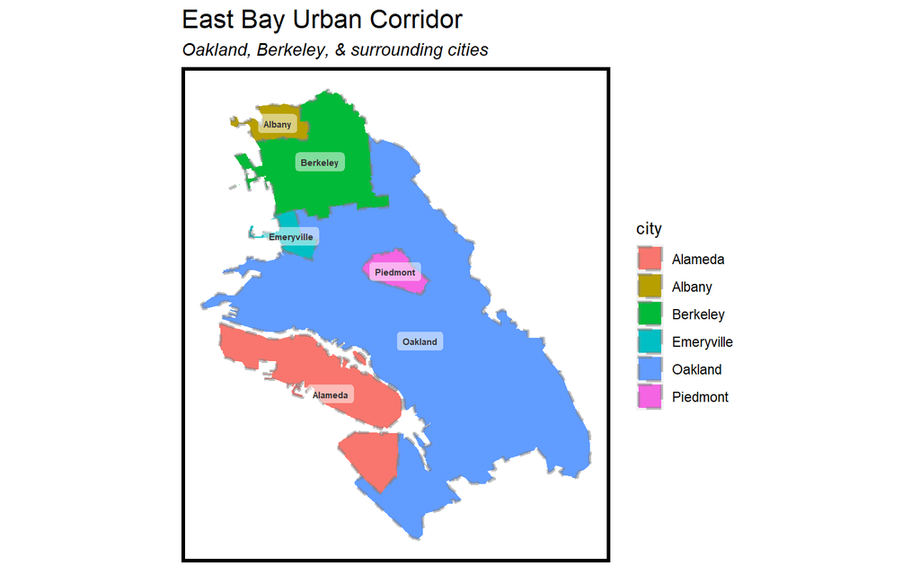

```r
library(tidycensus)
library(sf)
## Linking to GEOS 3.9.0, GDAL 3.2.1, PROJ 7.2.1
library(sp)
library(tmap)
library(ggrepel)
library(tigris)
## To enable
## caching of data, set `options(tigris_use_cache = TRUE)` in your R script or .Rprofile.

# tracts.all %>% group_by(year) %>%
#   summarize(
#     units = sum(tot_units),
#     pop = sum(tot_pop)
#   )

mile = 5280
sqmile = 27878400

set.seed(717)

mapTheme <- function(base_size = 12) {
  theme(
    text = element_text( color = "black"),
    plot.title = element_text(size = 16,colour = "black"),
    plot.subtitle=element_text(face="italic"),
    plot.caption=element_text(hjust=0),
    axis.ticks = element_blank(),
    panel.background = element_blank(),axis.title = element_blank(),
    axis.text = element_blank(),
    axis.title.x = element_blank(),
    axis.title.y = element_blank(),
    panel.grid.minor = element_blank(),
    panel.border = element_rect(colour = "black", fill=NA, size=2),
    strip.text.x = element_text(size = 14))
}

plotTheme <- function(base_size = 12) {
  theme(
    text = element_text( color = "black"),
    plot.title = element_text(size = 16,colour = "black"),
    plot.subtitle = element_text(face="italic"),
    plot.caption = element_text(hjust=0),
    axis.ticks = element_blank(),

    panel.background = element_blank(),
    panel.grid.major = element_line("grey80", size = 0.1),
    panel.grid.minor = element_blank(),
    panel.border = element_rect(colour = "black", fill=NA, size=2),
    strip.background = element_rect(fill = "grey80", color = "white"),
    strip.text = element_text(size=12),

    axis.title = element_text(size=12),
    axis.text = element_text(size=10),


    plot.background = element_blank(),

    legend.background = element_blank(),
    legend.title = element_text(colour = "black", face = "italic"),
    legend.text = element_text(colour = "black", face = "italic"),

    strip.text.x = element_text(size = 14)
  )
}

key_file = "C:/Users/nelms/OneDrive/Code/census_api_key.txt"
census_key = readChar(key_file, file.info(key_file)$size)
census_api_key(census_key, overwrite = TRUE)
## To install your API key for use in future sessions, run this function with `install = TRUE`.

# PULL CITY BOUNDARIES FROM REGIONAL MTC OPEN DATA
#city_path = 'https://services3.arcgis.com/i2dkYWmb4wHvYPda/arcgis/rest/services/region_jurisdiction_clp/FeatureServer/0/query?where=1%3D1&outFields=jurname,fipco&outSR=2227&f=geojson'
city_path = 'C:/Users/nelms/OneDrive/Penn/MUSA-508/Files/EastBay_cities.geojson'
EB.cities = st_read(city_path)
## Reading layer `EastBay_cities' from data source
##   `C:\Users\nelms\OneDrive\Penn\MUSA-508\Files\EastBay_cities.geojson'
##   using driver `GeoJSON'
## Simple feature collection with 109 features and 2 fields
## Geometry type: MULTIPOLYGON
## Dimension:     XY
## Bounding box:  xmin: 5696728 ymin: 1785314 xmax: 6355025 ymax: 2507172
## Projected CRS: NAD83 / California zone 3 (ftUS)

# NARROW AREAS TO MAJOR & MINOR CITIES
major_EB = c('Berkeley', 'Oakland')
minor_EB = c('Alameda', 'Albany', 'Emeryville', 'Piedmont')
is_EB = c(minor_EB, major_EB)
EB.cities = EB.cities[match(is_EB, EB.cities$jurname), ] %>%
  select( -fipco) %>%
  rename(
    city = jurname
  ) %>%
  st_transform(., 2227)

# Projection is (NAD83) California State Plan, Zone 3 (in FEET)
# EPSG:2226
CA_crs = st_crs(EB.cities)

EB.cities$size = 'minor'
EB.cities[EB.cities$city %in% major_EB, 'size'] = 'major'

# CREATE CITY LABELS
EB.labels =
  EB.cities %>%
  st_centroid(EB.cities) %>%
  rename(
    label = city
  ) %>%
  mutate(
       lon = map_dbl(geometry, ~st_centroid(.x)[[1]]),
       lat = map_dbl(geometry, ~st_centroid(.x)[[2]])
     )

plot_limits = function(
  poly.geometry = EB.cities$geometry,
  # buffer between plot's limits and the geometry
  # (in unit of geometry column)
  buffer = 0
){
  # creates bounding box
  poly.bbox =
    poly.geometry %>% st_union() %>%
    # buffers the geometry so the ultimate plot has margins
    st_buffer(buffer) %>%
    st_bbox()
  return(
    # returns the 'coord_sf' function which you can add to any plot
    coord_sf(
      xlim = c(poly.bbox['xmin'], poly.bbox['xmax']),
      ylim = c(poly.bbox['ymin'], poly.bbox['ymax']),
      crs = st_crs(poly.geometry)
  ))}

ggplot() +
  # cities
  geom_sf(data=EB.cities, aes(fill=city),
          color=alpha('grey50',.5),
          lwd=1, linetype = "dashed") +
  # labels
  geom_label(
    data=EB.labels,
    size = 2, fontface='bold', color='grey20', label.size = NA,
    box.padding = 0.5, fill=alpha('white',.5),
    aes(x=lon,y=lat, label=label)) +
  labs(
    title = 'East Bay Urban Corridor',
    subtitle = 'Oakland, Berkeley, & surrounding cities') +
  mapTheme() + plot_limits()
```

The following study examines some of the surface level indicators of the housing crisis and its resulting displacement. The study will focus on Transit Oriented Developments around Bay Area Rapid Transit stations — specifically, to understand if TOD housing is relieving the housing crisis or exacerbating the displacement of local residents. The study will: (Section 1) establish the variables and parameters; (Section 2) spatially compare five American Community Survey (ACS) variables between 2009 and 2019; (Section 3 & Section 4) make overall comparisions of TOD and non-TOD areas; (Section 5) utilize graduated symbol maps to evaluate specific station TOD areas; (Section 6) compare the distance to BART to both Mean Rent and the Amount of Homeless Encampment complaints; and, finally, (Section 7) evaluate all of the study components to give a picture of the East Bay housing crisis.

# 1 Variables & Parameters

This study is bringing in three primary data sources: (1.1) the San Francisco Bay Area’s hybrid subway-commuter rail, the Bay Area Rapid Transit (BART), to find TOD areas; (1.2) American Community Survey (ACS) Variables & Census Tracts to get core information; and (1.3) bring in Homeless Encampment complaints from the City of Oakland’s 311 citizen hotline.

## 1.1 Transit Routes & Stops

This study’s use of BART allows a focus on both urban centers and their immediate suburbs. The data was sourced from the regional [Metropolitan Transportation Commission](https://opendata.mtc.ca.gov/).

```r
#stop_path = "https://services3.arcgis.com/i2dkYWmb4wHvYPda/arcgis/rest/services/transitstops_existing_planned_2021/FeatureServer/0/query?where=1%3D1&outFields=*&outSR=2227&f=geojson"
stop_path = 'C:/Users/nelms/OneDrive/Penn/MUSA-508/Files/SF-Bay_Transit-Stops-Major_2021.geojson'

#route_path = "https://services3.arcgis.com/i2dkYWmb4wHvYPda/arcgis/rest/services/transitroutes_01_2020/FeatureServer/0/query?where=1%3D1&outFields=*&outSR=2227&f=geojson"
route_path = 'C:/Users/nelms/OneDrive/Penn/MUSA-508/Files/BART_routes.geojson'

BART.stops =
  # from the MTC API, who sourced it from BART
  st_read(stop_path) %>%
  # only look at BART & weekday routes
  filter(agency_id == "BA", route_s_nm!="Blue-Sun", route_s_nm!='Beige') %>%
  mutate(
    route_s_nm = ifelse(
      route_s_nm=="Blue-Wkd/Sat", "Blue",
      route_s_nm)
  ) %>%
  st_transform(., 2227)
## Reading layer `Transit_Stops_-_Major_(2021)' from data source
##   `C:\Users\nelms\OneDrive\Penn\MUSA-508\Files\SF-Bay_Transit-Stops-Major_2021.geojson'
##   using driver `GeoJSON'
## Simple feature collection with 5115 features and 18 fields
## Geometry type: POINT
## Dimension:     XY
## Bounding box:  xmin: -122.8172 ymin: 37.00348 xmax: -121.5661 ymax: 38.54765
## Geodetic CRS:  WGS 84

# Projection is (NAD83) California State Plan, Zone 2 (in FEET)
# EPSG:2226
CA_crs = st_crs(BART.stops)
#cat(CA_crs$input, ', EPSG:', CA_crs$epsg)

BART.routes =
  st_read(route_path) %>%
  filter(agency_id == "BA", route_s_nm!="Blue-Sun") %>%
  mutate(
    route_s_nm = ifelse(
      route_s_nm=="Blue-Wkd/Sat", "Blue",
      route_s_nm)
  ) %>%
  st_transform(., CA_crs)
## Reading layer `BART_routes' from data source
##   `C:\Users\nelms\OneDrive\Penn\MUSA-508\Files\BART_routes.geojson'
##   using driver `GeoJSON'
## Simple feature collection with 2000 features and 8 fields
## Geometry type: MULTILINESTRING
## Dimension:     XY
## Bounding box:  xmin: 5908167 ymin: 1815066 xmax: 6277273 ymax: 2407672
## Projected CRS: NAD83 / California zone 3 (ftUS)

# NARROW STOPS TO .5 MILE OUTSIDE THESE CITIES
BART.stops =
  BART.stops %>%
  # .5 mile buffer + 1 foot
  st_filter(., st_buffer(st_union(EB.cities), dist=5280*.5+1)) %>%
  group_by(stop_nm,stop_id) %>%
  st_drop_geometry(.) %>%
  summarise(
    route_count = n_distinct(route_s_nm), # get routes used
    routes      = list(unique(route_s_nm))
  ) %>%
  merge(., BART.stops[,'stop_id'], by='stop_id') %>%
  distinct() %>% # remove duplicates
  st_as_sf()

# NARROW STOPS TO THESE CITIES
BART.routes = st_intersection(BART.routes, st_buffer(st_union(EB.cities),5280*.5))
```

The BART stations will serve as the center of TOD areas — with the ultimate area being tracts mostly within a ½ mile buffer of BART. See Figure 1.1 & 1.2 in Section 1.2, for a graphical understanding of this selection.

```r
buffer_distance = .5

min_point_distances = function(
  input.geoms,
  input.ids,
  compare.geoms,
  compare.ids
){
  # GET DISTANCES OF TRANSIT STOPS AND THE FOCUS AREA BOUNDARY
  distances_matrix =
    outer(input.geoms,
          compare.geoms,
          FUN=Vectorize(st_distance, USE.NAMES = FALSE))

  # CREATE MATRIX COLUMN & ROW NAMES
  rownames(distances_matrix) = input.ids
  colnames(distances_matrix) = compare.ids

  get_col = function(rowname, find_num){
    return(colnames(distances_matrix)[distances_matrix[rowname, ] == find_num])
  }
  get_col = Vectorize(get_col)
  distances_df =
    apply(distances_matrix, 1, min) %>% as.data.frame() %>%
    rename('distance'=1) %>%
    rownames_to_column('ID') %>%
    mutate(closest=get_col(ID, distance))

  return(distances_df)
}

EB.coords = EB.cities %>%
    st_convex_hull() %>%
    st_cast(., "MULTIPOINT") %>%
    st_union() %>%
    st_cast(., "POINT")

BARTstop_EBboundary_distances = min_point_distances(
  input.geoms = EB.coords,
  input.ids   = seq(from=1,to=length(EB.coords)),
  compare.geoms = BART.stops$geometry,
  compare.ids = BART.stops$stop_id
)

# GET LARGEST CLOSEST DISTANCE (MILES) BETWEEN STOPS AND BOUNDARY
max_min_BART_EB_dist =
  max(BARTstop_EBboundary_distances$distance)/mile

# MINIMUM DISTANCE NEEDED TO BUFFER FROM TRANSIT STOPS AND COVER ALL FOCUS AREAS
# ASSUMES IN 1/2 or 1 MILE INTERVALS
buffer_max_distance = ceiling(max_min_BART_EB_dist)

# FUNCTION CREATING MULTIPLE RING BUFFERS FOR TRANSIT STOPS
# CYCLES THROUGH EACH DISTANCE ROW TO BUFFER & UNION
multiringbuffers_byrow = function(
  input.points, # BART Stops or any point
  buffer_distance=.5,
  buffer_max=5,
  # default fields & info for union
  union_default = data.frame(
    stop_id=c('ALL'),stop_nm=c('UNION'),
    route_count=c(0),routes=c(''))
){
  mile=5280
  # SEQUENCE VECTOR OF BUFFER RING LENGTHS
  buffer_distances =
    seq(from=buffer_distance,
        to=buffer_max, by=buffer_distance)

  # CYCLE THROUGH DISTANCES TO BUFFER EACH POINT
  # USE ST_DIFFERENCE TO CREATE RINGS
  # CREATE UNION ROW OF EACH DISTANCE
  for (current_buffer_distance in buffer_distances) {
    # GEOM OF SMALLER DISTANCE TO CREATE RING
    buffer.difference =
      input.points %>%
        st_buffer(
          (current_buffer_distance-buffer_distance)*mile
          ) %>% st_union() %>% st_sfc()
    # SF BUFFER OF EACH STOP
    buffer.new =
      input.points %>%
      st_buffer(., current_buffer_distance*mile) %>%
        st_difference(., buffer.difference) %>%
      mutate(distance = current_buffer_distance)

    # SF BUFFER UNION FOR NEW ROW
    buffer.union =
      buffer.new %>%
        st_union() %>%
        st_difference(., buffer.difference) %>%
        st_sfc() %>%
      # cbind default union fields
      cbind(
        ., union_default %>%
          mutate(distance=current_buffer_distance)
        ) %>% st_as_sf() %>%
      # reorder columns for rbind
      subset(., select=colnames(buffer.new))

    # rbind to all buffers
    if (current_buffer_distance==buffer_distance) {
      buffer.temp =
        st_as_sf(rbind(
          buffer.union,
          buffer.new))}
    else
      buffer.temp =
      st_as_sf(rbind(
        buffer.temp,
        buffer.union,
        buffer.new))
  }
  # reset index
  row.names(buffer.temp) <- NULL
  return(buffer.temp)
}

buffer_distance = .5
BART.buffers =
  multiringbuffers_byrow(
    BART.stops, buffer_distance=buffer_distance,
    buffer_max=buffer_max_distance)

buffer_distances =
  seq(from=buffer_distance, to=buffer_max_distance, by=buffer_distance)


buffer_breaks = c(0,buffer_distances)
buffer_labels =
  c(gsub("0.", ".", buffer_breaks))
#buffer_breaks = c(buffer_distances,buffer_max_distance+buffer_distance)
```